# Test+a+Perceptual+Phenomenon+zh

### 统计学：检验心理学现象

在下方单元格中回答问题并执行相关代码，你可以 参考项目指导 并在正式提交前查看 [项目要求](https://review.udacity.com/#!/rubrics/305/view)。提交时请将 Jupyter notebook 导出成 HTML 或者 PDF 进行提交（File -> Download As）。

背景信息

在一个Stroop （斯特鲁普）任务中，参与者得到了一列文字，每个文字都用一种油墨颜色展示。参与者的任务是将文字的打印颜色大声说出来。这项任务有两个条件：一致文字条件，和不一致文字条件。在一致文字条件中，显示的文字是与它们的打印颜色匹配的颜色词，如“红色”、“蓝色”。在不一致文字条件中，显示的文字是与它们的打印颜色不匹配的颜色词，如“紫色”、“橙色”。在每个情况中，我们将计量说出同等大小的列表中的墨色名称的时间。每位参与者必须全部完成并记录每种条件下使用的时间。

调查问题

作为一般说明，请确保记录你在创建项目时使用或参考的任何资源。作为项目提交的一部分，你将需要报告信息来源。

(1) 我们的自变量是什么？因变量是什么？

--自变量：文字内容与油墨颜色是否一致。即一致文字条件，还是不一致文字条件--  
--因变量：说出油墨颜色的时间--

(2) 此任务的适当假设集是什么？你需要以文字和数学符号方式对假设集中的零假设和对立假设加以说明，并对数学符号进行定义。你想执行什么类型的统计检验？为你的选择提供正当理由（比如，为何该实验满足你所选统计检验的前置条件）。

--零假设:不一致文字条件时 说出油墨颜色所用时间的总体均值，小于等于一致文字条件时 说出油墨颜色所用时间的总体均值--  
--对立假设:不一致文字条件时 说出油墨颜色所用时间的总体均值，大于一致文字条件时 说出油墨颜色所用时间的总体均值--  
--H0:μi-μc≤0--  
--H1:μi-μc＞0--  
--想要执行双样本配对t检验，通过两个相关样本测试总体的均数差。--  
--为何该实验满足你所选统计检验的前置条件：此实验有两个相关样本，在大样本的情况下，均值差满足正态分布假设。此实验满足双样本配对t检验前置条件

现在轮到你自行尝试 Stroop 任务了。前往此链接，其中包含一个基于 Java 的小程序，专门用于执行 Stroop 任务。记录你收到的任务时间（你无需将时间提交到网站）。现在下载此数据集，其中包含一些任务参与者的结果。数据集的每行包含一名参与者的表现，第一个数字代表他们的一致任务结果，第二个数字代表不一致任务结果。

(3) 报告关于此数据集的一些描述性统计。包含至少一个集中趋势测量和至少一个变异测量。

```python
import pandas as pd
import numpy as np
import scipy.stats as stats
import matplotlib.pyplot as plt
% matplotlib inline
```

```python
df=pd.read_csv("stroopdata.csv")
df.head()
```

|  | Congruent | Incongruent |
| --- | --- | --- |
| 0 | 12.079 | 19.278 |
| 1 | 16.791 | 18.741 |
| 2 | 9.564 | 21.214 |
| 3 | 8.630 | 15.687 |
| 4 | 14.669 | 22.803 |

```python
df.shape
```

```
(24, 2)
```

```python
# 此数据集的集中趋势测量：平均值
df.Congruent.mean()
```

```
14.051125000000004
```

```python
df.Incongruent.mean()
```

```
22.01591666666667
```

```python
df.Incongruent.mean()-df.Congruent.mean()
```

```
7.964791666666665
```

```python
# 此数据集的变化测量：标准差
np.std(df.Congruent)
```

```
3.4844157127666326
```

```python
np.std(df.Incongruent)
```

```
4.696055134513317
```

--此数据集的一些描述性统计--

--集中趋势测量：平均值  
一致文字条件时，说出油墨颜色所用时间的平均值14.0511  
不一致文字条件时，说出油墨颜色所用时间的平均值接近22.0159  
一致文字条件同不一致文字条件，说出油墨颜色所用时间差的平均值7.96479

变化测量：标准差  
一致文字条件时，说出油墨颜色所用时间的标准差3.484  
不一致文字条件时，说出油墨颜色所用时间的标准差4.696--

(4) 提供显示样本数据分布的一个或两个可视化。用一两句话说明你从图中观察到的结果。

```python
means_con=[]
means_inc=[]
diff=[]
for i in range(10000):
    bootsample=df.sample(1000,replace=True)
    mean_con=bootsample.Congruent.mean()
    mean_inc=bootsample.Incongruent.mean()
    means_con.append(mean_con)
    means_inc.append(mean_inc)
    diff.append(mean_inc-mean_con)
```

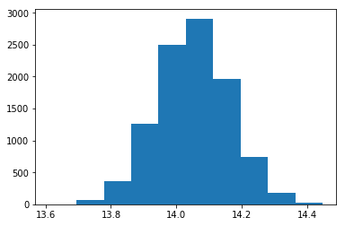

```python
# 在这里创建可视化图表
plt.hist(means_con);
```

--通过观察上图，一致文字条件时，说出油墨颜色所用总体时间的平均值范围大约在13.7s-14.4s之间，平均值在14s左右最集中。--

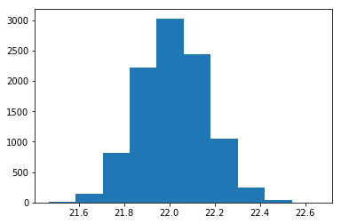

```python
plt.hist(means_inc);
```

--通过观察上图，不一致文字条件时，说出油墨颜色所用总体时间的平均值范围大约在21.5s-22.5s之间，平均值在22s左右最集中。--

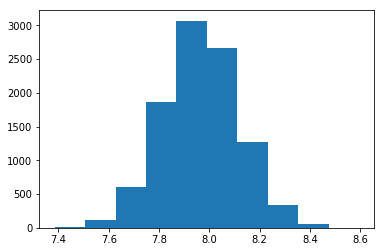

```python
# 统计量的差异
plt.hist(diff);
```

--通过观察上图，一致文字条件与不一致文字条件，说出油墨颜色所用总体时间的差的平均值范围大约在7.4s-8.4s之间，平均值在8s左右最集中。--

```python
# 零假设中抽样分布的差异
null_value=np.random.normal(0,np.std(diff),10000)
```

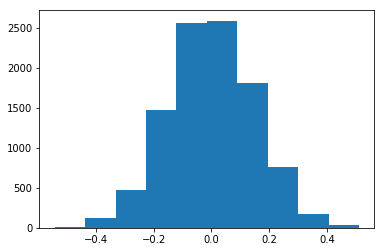

```python
plt.hist(null_value);
```

--通过对比统计量的差异和零假设中抽样分布的差异：零假设的差值不在统计量中，统计量的差值大于零假设的差值。我们应该拒绝H0。--

(5) 现在，执行统计测试并报告你的结果。你的置信水平和关键统计值是多少？你是否成功拒绝零假设？对试验任务得出一个结论。结果是否与你的期望一致？

--设置置信水平α=0.05，因为H1:μi-μc＞0，则t临界值为单侧--

```python
# t统计量,计算两个相关的分数样本a和b的T检验
b=df.Congruent
a=df.Incongruent
stats.ttest_rel(a,b)
```

```
Ttest_relResult(statistic=8.020706944109957, pvalue=4.1030005857111781e-08)
```

--双尾的t统计量是8.020706944109957--  
--单尾的α=0.05，则查看双尾的α=0.10的t临界值。--  
--两个相关样本的df=样本容量-1=24-1=23，df=23。--  
--单尾的α=0.05，df=23的t临界值是1.714。t统计量为8.020706944109957，在t临界区域内，具有统计显著性。--  
--双尾p值是4.1030005857111781e-08，单尾p值是双尾p值除以2，单尾p值是2.051500292855589e-08，α=0.05，p值<α，具有统计显著性。--

--所以，我们应该拒绝零假设，选择对立假设。在此案例中，我们应该认为不一致文字条件时，说出油墨颜色所用时间的总体均值，大于一致文字条件时，说出油墨颜色所用时间的总体均值--  
--实验结果与我预期的一致--